# Target Trial Emulation Example

Designing an observational analysis against an ideal trial

# Study question

Among adult smokers at baseline, what would the average 11-year weight change have been under smoking cessation versus continued smoking?

This example shows the target trial question, the corresponding observational emulation, the main design assumptions, and the key ways the observed data differ from the ideal trial.

# Data source

**Source:** NHEFS

The National Health and Nutrition Examination Survey I Epidemiologic Follow-up Study (NHEFS) is a longitudinal follow-up of participants from the first NHANES survey.

This example uses the dataset object `causaldata::nhefs` in R.

- **Data type:** Longitudinal cohort follow-up dataset
- **Setting:** United States population-based epidemiologic follow-up study
- **Time period:** Baseline NHANES I measurements in the 1970s with follow-up through 1982

More information: - [R dataset documentation](https://rdrr.io/cran/causaldata/man/nhefs.html) - [Underlying data source](https://wwwn.cdc.gov/nchs/nhanes/nhefs/)

It was created for epidemiologic follow-up rather than for a smoking-cessation trial, which makes it useful for observational causal questions but also means the intervention, assignment process, and follow-up were not designed as a randomized protocol.

# Why emulate a target trial with these data

A randomized smoking-cessation trial with this exact long-term follow-up is not available here, but the cohort contains baseline smoking status, baseline covariates, and later weight-change outcomes, which makes it possible to specify a target trial and then evaluate how closely the observed data emulate it.

# Core protocol comparison

Hernan and Robins describe target trial emulation as making the protocol of the ideal trial explicit and then evaluating how well the observational analysis reproduces that protocol. A helpful reference for this structure is Miguel A. Hernan and James M. Robins, [“Using Big Data to Emulate a Target Trial When a Randomized Trial Is Not Available”](https://doi.org/10.1093/aje/kwv254), *American Journal of Epidemiology* 183(8):758-764, published March 18, 2016.

The table below is the center of the example. It places the ideal trial beside the observed emulation and then names the main alignment or departure for each protocol component.

This structure is also consistent with more recent methodological literature. Matthews et al. (2022) emphasize explicit specification of eligibility, treatment strategies, assignment, follow-up, outcomes, causal contrasts, and analysis plan; Fu (2023) highlights alignment of eligibility, treatment assignment, and start of follow-up as a central design requirement; Hansford et al. (2023) and Simon-Tillaux et al. (2024) found that many published target trial emulations still omit key protocol components or fail to clearly describe how the observational analysis matches the target trial; and Cashin et al., [“Transparent Reporting of Observational Studies Emulating a Target Trial-The TARGET Statement”](https://pubmed.ncbi.nlm.nih.gov/40899949/), *JAMA* 334(12):1084-1093, published September 23, 2025, provides a 21-item reporting checklist specifically for target trial emulations. TARGET is especially relevant here because it recommends paired reporting of the target trial specification and its emulation in the observational data.

| Component | Ideal target trial | Observed emulation | Main gap |
| --- | --- | --- | --- |
| Eligibility | Eligible baseline adult smokers under protocol-defined inclusion criteria. | Observed baseline smokers with complete covariate and outcome data. | Aligned in intent, but narrower because of data completeness restrictions. |
| Strategies | Sustained smoking cessation versus sustained continued smoking. | Observed quitting status versus observed continued smoking. | Conceptually aligned, but less precise than a protocol-defined sustained strategy. |
| Assignment | Random assignment at baseline. | No randomization; strategy inferred from observed behavior. | Major departure because treatment is not randomly assigned. |
| Time zero | Eligibility confirmation and strategy assignment at baseline. | Baseline survey measurement. | Reasonably aligned, though less tightly controlled than a trial baseline visit. |
| Follow-up | Prospective follow-up to a prespecified end under protocol rules. | Observed follow-up through 1982 among those with outcome data. | Partially aligned because missing outcome data can alter the represented population. |
| Outcome | Weight change measured consistently at follow-up. | Observed 1971 to 1982 weight change in NHEFS. | Broadly aligned in construct, but based on observational measurement. |
| Contrast | Average treatment effect under each assigned strategy. | Average treatment effect question for the eligible baseline cohort. | Aligned as a causal question, contingent on identification assumptions. |
| Analysis | Prespecified causal analysis aligned with assignment and follow-up. | Design-focused example with weighting, imputation, and censoring sensitivity analyses planned. | Only partially aligned because full protocol-driven estimation is not shown here. |

## Target trial protocol summary

| Component | Specification |
| --- | --- |
| Eligibility | Adults who were smoking at baseline and had baseline covariate and outcome follow-up data available. |
| Treatment strategies | Quit smoking between baseline and first follow-up versus continue smoking. |
| Time zero | Baseline measurement when smoking status and covariates are assessed. |
| Outcome | Weight change from 1971 to 1982. |
| Follow-up | Through the observed 11-year follow-up window. |
| Estimand | Average treatment effect of smoking cessation on weight change. |
| Causal contrast | A per-protocol style contrast using observed cessation status as the intervention indicator. |
| Analysis plan | Start with covariate-adjusted outcome modeling and later compare with weighting and censoring-weight extensions. |
| Primary bias risks | Confounding by health status and smoking history, selection from missing follow-up, and exposure misclassification. |

## Key departures from the ideal trial

- Treatment assignment is observed rather than randomized.
- The intervention is operationalized from recorded behavior rather than protocol-defined adherence.
- The analytic cohort depends on observed data completeness.
- Follow-up is limited to the available outcome window in the dataset.

## Estimand

The primary estimand is the average difference in 11-year weight change if baseline smokers quit versus if those same smokers had continued smoking.

This is intentionally phrased as a question about the population represented by the eligible baseline cohort, rather than a subgroup discovered after the fact.

## Key identification assumptions

- Exchangeability: after adjustment for measured baseline covariates, treatment strategy groups are sufficiently comparable.
- Positivity: each treatment strategy remains possible within the covariate strata represented in the observed data.
- Consistency: the observed treatment definition is a usable proxy for the intervention strategy described in the target trial.
- Missingness assumptions: the primary missing-data analysis treats missing values as plausibly missing at random conditional on observed variables included in the imputation model, with sensitivity analyses for departures from that assumption.

# Supporting design details

## Cohort construction

| Stage | N |
| --- | --- |
| Rows in source dataset | 1629 |
| Rows with observed treatment status | 1629 |
| Rows with complete baseline and outcome variables | 1566 |
| Final analytic cohort | 1566 |

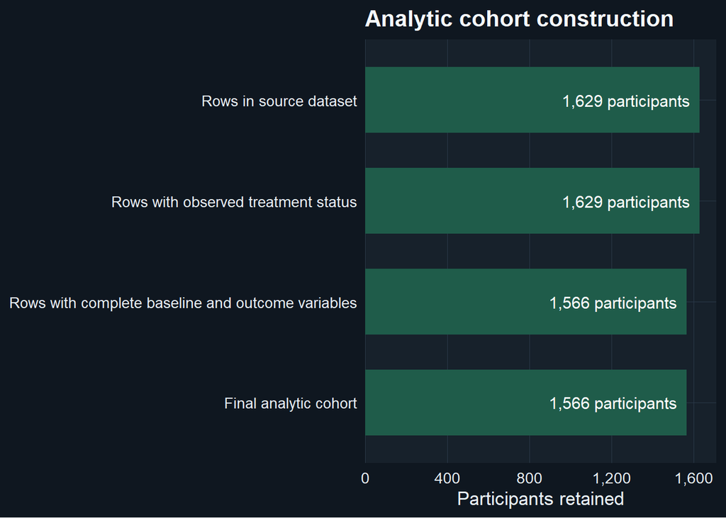

The cohort flow shows how eligibility and observed data availability shape the analytic cohort.

## Missingness snapshot

| Variable | Missing N | Missing % |
| --- | --- | --- |
| outcome_wt_change | 63 | 3.9 |

Recent methodological work is more supportive of multiple imputation than pure complete-case analysis when causal questions involve multivariable missingness. Mainzer et al. (2024) describe multiple imputation as a widely recommended approach in this setting, and Zhang et al. (2023) compare multiple imputation strategies for causal effect estimation with outcome regression. For missing outcomes specifically, Groenwold et al. (2012) and Sullivan et al. (2017) support imputation-based approaches under explicit assumptions, while also showing that performance depends on the imputation model and estimand. In this example, the preferred strategy is multiple imputation as the primary missing-data approach, including outcome imputation when assumptions are judged plausible, with complete-case and alternative-assumption analyses treated as sensitivity checks rather than defaults.

## Covariate adjustment rationale

| Covariate | Role in design | Why it belongs |
| --- | --- | --- |
| age | Baseline demographic confounder | Age influences both probability of cessation and long-term weight change. |
| sex | Baseline demographic confounder | Sex may shape cessation patterns and subsequent weight trajectories. |
| race | Baseline demographic and structural confounder | Race may proxy structural and behavioral differences tied to treatment uptake and outcome risk. |
| education | Socioeconomic proxy and health behavior proxy | Educational attainment is related to smoking behavior, quitting success, and general health patterns. |
| smokeintensity | Smoking burden confounder | Heavier smoking can predict both difficulty quitting and downstream metabolic or behavioral change. |
| smokeyrs | Smoking history confounder | Longer smoking history can influence baseline health and the likelihood of successful cessation. |
| wt71 | Baseline health status marker | Baseline weight is strongly related to subsequent weight change and may also correlate with quitting behavior. |
| baseline_bmi | Baseline health status marker | BMI provides an alternative baseline health summary beyond raw weight alone. |
| exercise | Health behavior proxy | Exercise level may affect both likelihood of cessation and later weight change. |
| active | Functional status and health behavior proxy | General activity level may proxy baseline health, function, and lifestyle. |

The adjustment set should be defendable from the design, not only from model fit.

## Analytic cohort snapshot

| Metric | Value |
| --- | --- |
| Analytic cohort size | 1,566 |
| Smoking cessation count | 403 |
| Continued smoking count | 1,163 |
| Mean age | 43.7 |
| Mean baseline weight (kg) | 70.8 |

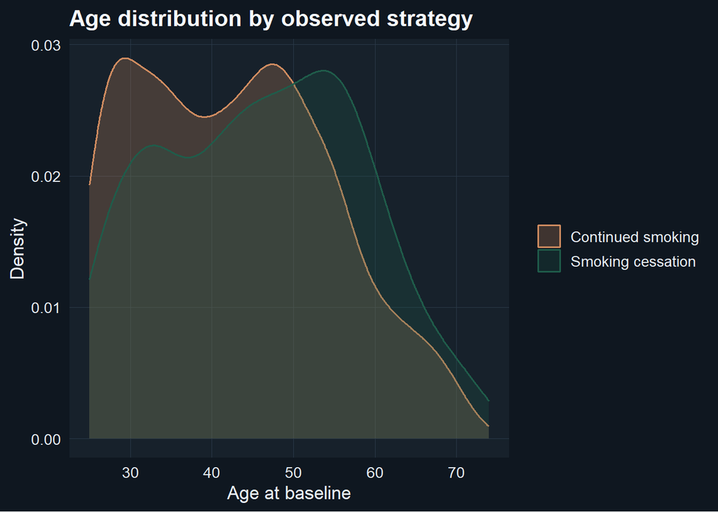

## Bias risks and planned responses

| Bias risk | Why it matters | Planned response |
| --- | --- | --- |
| Baseline confounding | People who quit smoking or enter training may differ systematically from comparators before treatment starts. | Use rich baseline covariate adjustment and explain the role of exchangeability assumptions. |
| Selection during follow-up | Complete-case analysis and loss to follow-up can change who remains represented in the final contrast. | Describe cohort construction clearly and consider inverse probability of censoring weights in a later extension. |
| Intervention misclassification | Observed exposure indicators may not fully capture protocol adherence, timing, or persistence. | State the operational treatment definition directly in the protocol table. |
| Outcome interpretation | Even a well-designed emulation still relies on assumptions that should be made explicit to readers. | Keep conclusions design-aware and avoid causal overclaiming. |

## Sensitivity-analysis roadmap

| Planned sensitivity analysis | Purpose | Design risk addressed | What success looks like |
| --- | --- | --- | --- |
| Propensity-score weighting comparison | Check whether a design-adjusted estimate is directionally similar under a different confounding-control strategy. | Baseline confounding | The estimated effect is broadly consistent in direction and practical magnitude. |
| Censoring or follow-up weighting extension | Evaluate whether differential follow-up or complete-case restriction is altering the target contrast. | Selection during follow-up | Inference does not change materially after accounting for follow-up selection. |
| Multiple-imputation primary analysis | Handle missing covariates and outcomes under an explicit imputation model instead of relying on complete-case restriction. | Missingness and selection | Results remain interpretable after multiple imputation and are not driven by complete-case restriction alone. |
| Alternative functional form check | Test whether conclusions depend heavily on linear modeling assumptions for baseline covariates. | Model misspecification | The treatment contrast is not an artifact of a single rigid regression specification. |

This roadmap shows how the analysis would progress into a more decision-ready causal study.

## Interpretation

This example is intentionally design-first. In a fuller study, the next layer would add estimation, overlap diagnostics, multiple-imputation implementation details, and sensitivity analyses.

## What I would do next in a real study

- justify each baseline covariate with a short causal role description
- add inverse probability weighting and censoring-weight sensitivity analyses
- implement multiple imputation as the primary missing-data analysis and compare it with complete-case and alternative-assumption sensitivity analyses
- document where residual bias is most likely to remain

## Current limitations

| Note |
| --- |
| Smoking cessation is not randomized, so baseline health and smoking burden are likely confounders. |
| Observed exposure definitions are coarser than an ideal protocol-defined intervention. |
| Loss to follow-up and data restrictions may shift the target population. |
| Multiple imputation is a reasonable primary strategy for missing data when its assumptions are made explicit and sensitivity analyses are reported. |